# Introducción

La herramienta para generación de años meteorológicos típicos a partir de datos horarios “TMY-Generator” es puesta a disposición bajo licenciamiento Creative Commons. La versión 0.4.0 se encuentra en fase de pruebas, por lo tanto se esperan modificaciones en el futuro.

Esta aplicación web permite que el usuario analice una base meteorológica de datos horarios y obtenga como resultado el conjunto de datos correspondiente a un año meteorlógico típico.

Este **Manual de Usuario** describe las diferentes secciones que componen la interacción de la herramienta con el usuario. Así se pretende lograr un mejor entendimiento de la herramienta.

# Descripción de las diferentes secciones y su funcionalidad

La aplicación consta de dos partes generales: La primera corresponde a las configuraciones generales que el usuario debe realizar; mientras que la segunda parte es el resultado del procesamiento de la información ingresada en la primera parte. La figura a continuación muestra una vista general de la herramienta resaltando las diferentes secciones de la misma.

A continuación se describirán las diferentes secciones:

## Entradas de Datos

La primera parte está conformada por las secciones:

`Sección 1:` *Table input*

`Sección 2:` *Period Settings*

`Sección 3:` *Table Settings*

`Sección 4:` *Weighting for Filkenstein’Schaffer*

[figure not shown]

### `Sección 1:`*Table input*

> La Sección 1 corresponde a los datos de entrada de la herramienta, la misma recibe un fichero el cual es procesado para extraer la información del mismo.

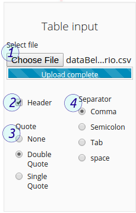

1. Funcionalidad para seleccionar el fichero que se desea leer.
2. Identifica si el fichero posee cabeceras. Las cabeceras son tomadas de la primera linea del fichero que identifica con este nombre el dato de las diferentes columnas.
3. Delimitador de Texto para identificar 1 dato.
4. Delimitador utilizado para separar las diferentes columnas de los datos.

### `Sección 2:` *Period Settings*

> La Sección 2 es la encargada de establecer el rango de fechas entre el cual se desea estudiar la información.

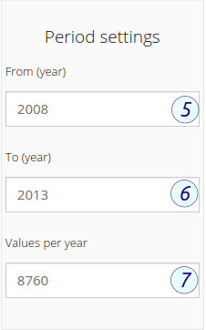

5. Especifica la fecha de inicio del periodo que se desea estudiar, debe coincidir con la primera fecha de inicio que posea el fichero a procesar.
6. Especifica la fecha de fin del periodo que se desea estudiar, debe coincidir con la última fecha que posea el fichero procesado.
7. Cantidad de Horas por Año que aparecen en el fichero procesado.

### `Sección 3:` *Table Settings*

> La Sección 3 esta referida a la configuración de las variables según la cantidad de columnas y la organización de los datos por columnas en el fichero procesado. Se debe hacer coincidir el número de la variable con la columna del fichero.

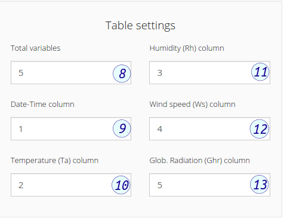

### `Sección 4:` *Weighting for Filkenstein’Schaffer*

> La Sección 4 hace Referencia a los distintos valores que pueden ser ajustados para otorgarle una ponderación particular a las diferentes variables y en función de estos valores calcular el año meteorológico típico, tenga presente que la sumatoria de todos los valores debe dar como resultado final 100, por defecto carga los valores especificados en el método.

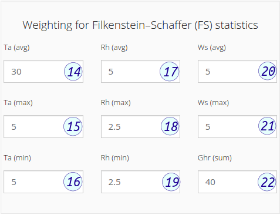

## Salida de Datos:

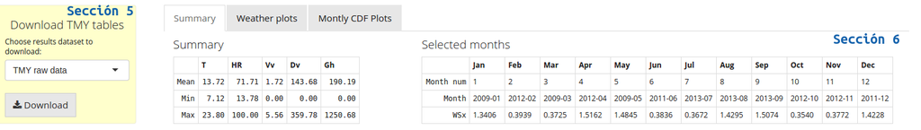

### `Sección 5:` *Download TMY tables*

> La Sección 5 es referente a la descarga de la información que se genera de los años meteorológicos típicos.

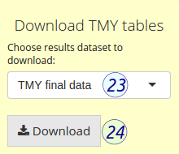

23. El Campo 23 representa las diferentes opciones que se tiene para realizar la descarga.
24. El Campo 24 representa la opción para realizar la descargar de un nuevo fichero en formato CSV.

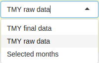

**Opciones Campo 23**

. TMY final data exporta los datos de los meses que componen el año meteorológico típico con una corrección de los valores para que no exista un salto brusco en el limite de cada mes con el comienzo del próximo mes.

. TMY Raw data exporta los datos de los meses que componen el año meteorológico típico sin corrección de los valores.

. Selected months exporta la tabla de meses que componen el año meteorológico típico, son los mismos datos que se pueden observar en el resumen de la sección 6.

### `Sección 6:` *Graphic and Summary*

> Sección 6: La Sección 6 muestra el resumen y gráficos que son generados producto del procesamiento del fichero.

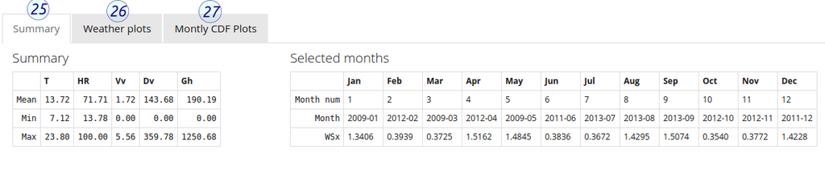

25. El Campo 25 muestra un resumen producto del procesamiento del fichero. Compuesto por 2 tablas, una tabla resumen de la media, mínimo y máximo de cada una de las variables por las que están compuestos los datos y otra tabla que muestra los meses que van a conformar el año meteorológico típico.
26. El Campo 26 muestra el comportamiento del año típico para la variable seleccionada, se utilizan las fechas del último año procesado pero esto representa el año típico calculado según el método, no el último año de los datos subidos.

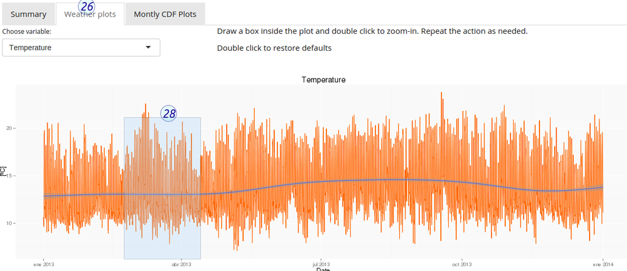

28. El Campo 28 muestra la funcionalidad que permite estudiar un rango especificado por el usuario. Haciendo doble clic se muestra en la gráfica pero con el rango seleccionado por el usuario. Cuando estemos en el periodo seleccionado haciendo doble clic podmos volver a restablecer el gráfico completo sin rango.

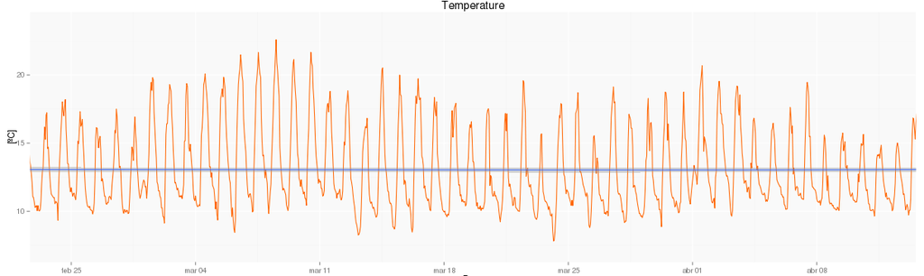

Imagen resultado de haber realizado doble clic sobre el rango seleccionado.

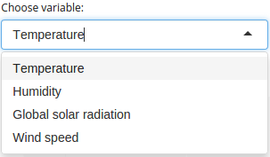

. Figura de las diferentes variables que componen el año meteorológico típico y que son opciones por las cuales se puede graficar.

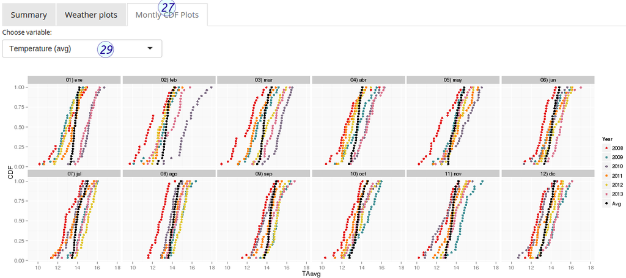

27. El Campo 27 muestra el comportamiento según la función de distribución de frecuencia acumulada para cada uno de los meses procesados, además muestra el promedio de los meses. Posee una leyenda la cual indica a que año pertenece cada mes y cual es el promedio.

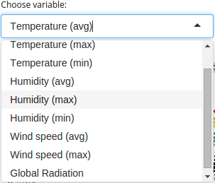